# Limpieza Datos

Briam Stiven

2026-11-14

# LIMPIEZA DE DATOS

En este documento se realiza la fase inicial de exploración y diagnóstico de calidad sobre el conjunto de datos (`dataset_clase_1.csv`), verificando su estructura, variables y posibles inconsistencias previas a la limpieza.

## 1. Verificación del Directorio de Datos

Antes de realizar la carga, exploramos qué archivos existen en la carpeta `Datos` mediante una ruta relativa:

```r
# Visualizo los archivos disponibles en la carpeta Datos
list.files("../Datos")
```

```
## [1] "dataset_clase_1.csv"
```

## 2. Carga del Conjunto de Datos

Cargamos el archivo CSV en la variable `data` para estructurarlo como un *data frame* en el entorno de trabajo:

```r
# En esta línea cargamos la matriz de datos
data <- read.csv("../Datos/dataset_clase_1.csv")
```

## 3. Exploración y Diagnóstico Inicial

### 3.1 Primeras observaciones

Inspeccionamos los primeros 6 registros para tener una vista previa del contenido y los valores de cada atributo:

```r
# Visualizamos las primeras filas
head(data)
```

```
##   ID Nombre  Apellido Edad Ingreso    Genero   Ciudad   Profesion
## 1  1   Juan     Pérez   25    1200 MASCULINO   Bogotá   Ingeniero
## 2  2    Ana     Gómez   30    1500  Femenino Medellín     Abogada
## 3  3 Carlos     Lopez   45    3000 MASCULINO     Cali      Medico
## 4  4  María Rodríguez   29      NA  FEMENINO   Bogotá     Docente
## 5  5  Pedro  Martinez   35   -2000 Masculino   bogotá Comerciante
## 6  6  Luisa Hernandez   NA    1800  FEMENINO     Cali   Ingeniera
##   Nivel_Educativo Estado_Civil Hijos               Email
## 1   Universitario      SOLTERO     0     juanp@gmail.com
## 2 Especialización       Casada     1 ana.gomez@gmail.com
## 3        Maestría       CASADO     2   carlosl@gmail.com
## 4   Universitario      Soltera     0     maria@gmail.com
## 5       Bachiller  UNION LIBRE     3     pedro@gmail.com
## 6   Universitario      Soltera     0     luisa@gmail.com
```

### 3.2 Dimensiones de la matriz

Consultamos la cantidad total de observaciones (filas) y atributos o características (columnas):

```r
# Retorna: [número de filas, número de columnas]
dim(data)
```

```
## [1] 30 12
```

### 3.3 Nombres de las variables

Identificamos los nombres asignados a cada una de las columnas del conjunto de datos:

```r
# Listado de nombres de columnas
colnames(data)
```

```
##  [1] "ID"              "Nombre"          "Apellido"        "Edad"
##  [5] "Ingreso"         "Genero"          "Ciudad"          "Profesion"
##  [9] "Nivel_Educativo" "Estado_Civil"    "Hijos"           "Email"
```

### 3.4 Estructura interna y tipos de datos

Examinamos el tipo de dato asignado por defecto a cada columna (numérico, texto, etc.) y una muestra de sus primeros valores:

```r
# Estructura general de las variables
str(data)
```

```
## 'data.frame':    30 obs. of  12 variables:
##  $ ID             : int  1 2 3 4 5 6 7 8 9 10 ...
##  $ Nombre         : chr  "Juan" "Ana" "Carlos" "María" ...
##  $ Apellido       : chr  "Pérez" "Gómez" "Lopez" "Rodríguez" ...
##  $ Edad           : num  25 30 45 29 35 NA 25 40 22 28 ...
##  $ Ingreso        : num  1200 1500 3000 NA -2000 1800 1200 50000 1100 1300 ...
##  $ Genero         : chr  "MASCULINO" "Femenino" "MASCULINO" "FEMENINO" ...
##  $ Ciudad         : chr  "Bogotá" "Medellín" "Cali" "Bogotá" ...
##  $ Profesion      : chr  "Ingeniero" "Abogada" "Medico" "Docente" ...
##  $ Nivel_Educativo: chr  "Universitario" "Especialización" "Maestría" "Universitario" ...
##  $ Estado_Civil   : chr  "SOLTERO" "Casada" "CASADO" "Soltera" ...
##  $ Hijos          : int  0 1 2 0 3 0 0 2 0 0 ...
##  $ Email          : chr  "juanp@gmail.com" "ana.gomez@gmail.com" "carlosl@gmail.com" "maria@gmail.com" ...
```

## 4. Análisis y Argumentación de Variables Cualitativas (Categóricas)

Para cada una de las variables cualitativas generamos su tabla de frecuencias ordenada de mayor a menor y documentamos los hallazgos e inconsistencias observadas.

### 4.1 Variable: Profesión

```r
# Tabla de frecuencias ordenada para Profesión
tabla_profesion <- data.frame(sort(table(data$Profesion), decreasing = TRUE))
colnames(tabla_profesion) <- c("Profesion", "Frecuencia")
tabla_profesion
```

```
##        Profesion Frecuencia
## 1      Ingeniero          8
## 2        Docente          3
## 3     Estudiante          3
## 4        Abogada          2
## 5  Administrador          2
## 6    Comerciante          2
## 7       Contador          2
## 8     Diseñadora          2
## 9     Empresario          2
## 10     Psicologa          2
## 11     Ingeniera          1
## 12        Medico          1
```

> **Argumentación y hallazgos en Profesión:** * **División por género gramatical:** Se cuenta por separado `Ingeniero` (8) e `Ingeniera` (1). Si el objetivo analítico es la ocupación, deberían consolidarse bajo una misma etiqueta. * **Ortografía / Tildes:** Faltan acentos ortográficos en `Medico` (Médico) y `Psicologa` (Psicóloga). * **Distribución:** La profesión predominante en la muestra es Ingeniería (9 registros en total), seguida de Docente y Estudiante (3 cada una).

### 4.2 Variable: Género

```r
# Tabla de frecuencias ordenada para Género
tabla_genero <- data.frame(sort(table(data$Genero), decreasing = TRUE))
colnames(tabla_genero) <- c("Genero", "Frecuencia")
tabla_genero
```

```
##      Genero Frecuencia
## 1 MASCULINO         16
## 2  Femenino          8
## 3  FEMENINO          5
## 4 Masculino          1
```

> **Argumentación y hallazgos en Género:** * **Inconsistencia de mayúsculas y minúsculas (*Case Sensitivity*):** R distingue entre mayúsculas y minúsculas, por lo que fragmenta la variable en cuatro categorías en lugar de dos: * Masculino: `MASCULINO` (16) y `Masculino` (1) -> Total: 17 * Femenino: `Femenino` (8) y `FEMENINO` (5) -> Total: 13 * **Acción requerida en limpieza:** Estandarizar el texto a un formato único (ejemplo: todo mayúsculas o tipo título como `Masculino` / `Femenino`).

### 4.3 Variable: Ciudad

```r
# Tabla de frecuencias ordenada para Ciudad
tabla_ciudad <- data.frame(sort(table(data$Ciudad), decreasing = TRUE))
colnames(tabla_ciudad) <- c("Ciudad", "Frecuencia")
tabla_ciudad
```

```
##     Ciudad Frecuencia
## 1   Bogotá         11
## 2     Cali          9
## 3 Medellín          8
## 4   bogota          1
## 5   bogotá          1
```

> **Argumentación y hallazgos en Ciudad:** * **Fragmentación por ortografía y mayúsculas:** La ciudad de Bogotá aparece dividida en 3 formas distintas: * `Bogotá` (11) con tilde y mayúscula inicial. * `bogotá` (1) en minúscula. * `bogota` (1) en minúscula y sin tilde. * En total son 13 registros de Bogotá, pero R los interpreta como tres ciudades diferentes. * **Acción requerida en limpieza:** Homogeneizar los nombres de las ciudades corrigiendo tildes y aplicando mayúscula inicial (`Bogotá`, `Cali`, `Medellín`).

### 4.4 Variable: Estado Civil

```r
# Tabla de frecuencias ordenada para Estado Civil
tabla_estado_civil <- data.frame(sort(table(data$Estado_Civil), decreasing = TRUE))
colnames(tabla_estado_civil) <- c("Estado_Civil", "Frecuencia")
tabla_estado_civil
```

```
##   Estado_Civil Frecuencia
## 1      Soltera         10
## 2       Casado          8
## 3      SOLTERO          4
## 4       Casada          3
## 5      Soltero          2
## 6       CASADO          1
## 7  Union libre          1
## 8  UNION LIBRE          1
```

> **Argumentación y hallazgos en Estado Civil:** * **Múltiples inconsistencias simultáneas:** * **Soltería:** Se divide en `Soltera` (10), `SOLTERO` (4) y `Soltero` (2) -> Total: 16. * **Matrimonio:** Se divide en `Casado` (8), `Casada` (3) y `CASADO` (1) -> Total: 12. * **Unión Libre:** Se divide en `UNION LIBRE` (1) y `Union libre` (1) -> Total: 2. * **Problemas identificados:** 1. Uso mixto de mayúsculas sostenidas y capitalizado. 2. Distinción innecesaria de género gramatical (`Casado`/`Casada`, `Soltero`/`Soltera`) que dispersa las categorías. * **Acción requerida en limpieza:** Reclasificar y homologar en tres categorías limpias: `Soltero`, `Casado` y `Unión Libre`.

### 4.5 Variable: Nivel Educativo

```r
# Tabla de frecuencias ordenada para Nivel Educativo
tabla_nivel_educativo <- data.frame(sort(table(data$Nivel_Educativo), decreasing = TRUE))
colnames(tabla_nivel_educativo) <- c("Nivel_Educativo", "Frecuencia")
tabla_nivel_educativo
```

```
##   Nivel_Educativo Frecuencia
## 1   Universitario         18
## 2 Especialización          6
## 3        Maestría          4
## 4       Bachiller          2
```

> **Argumentación y hallazgos en Nivel Educativo:** * **Consistencia óptima:** Es la única variable cualitativa que no presenta errores tipográficos, problemas de tildes ni dispersión por mayúsculas. * **Escala ordinal:** Los niveles presentes siguen una jerarquía clara: `Bachiller` (2) < `Universitario` (18) < `Especialización` (6) < `Maestría` (4). * **Predominio:** La gran mayoría de los registros cuenta con nivel `Universitario` (60%).

## 5. Resumen del Diagnóstico de Variables Cualitativas

En conclusión, la exploración inicial de las variables cualitativas revela los siguientes problemas recurrentes en la fuente de datos:

1. **Sensibilidad a mayúsculas y minúsculas (*Case Sensitivity*):** Afecta fuertemente a `Genero`, `Estado_Civil` y `Ciudad`.
2. **Errores tipográficos y ausencia de acentos:** Detectado en `Ciudad` (`bogota`) y `Profesion` (`Medico`, `Psicologa`).
3. **Redundancia por género gramatical:** Afecta a `Profesion` (`Ingeniero`/`Ingeniera`) y `Estado_Civil` (`Soltero`/`Soltera`, `Casado`/`Casada`).

## 6. Análisis y Argumentación de Variables Cuantitativas (Numéricas)

A diferencia de las variables cualitativas (que se estudian con tablas de frecuencias), las variables cuantitativas se analizan a través de medidas de tendencia central (media, mediana), posición (mínimo, máximo, cuartiles), dispersión, visualización gráfica (diagramas de caja e histogramas) y detección de valores faltantes (`NA`) o anomalías numéricas.

### 6.1 Resumen Estadístico Comparativo

```r
# Resumen descriptivo general de las variables cuantitativas
summary(data[, c("Edad", "Ingreso", "Hijos")])
```

```
##       Edad           Ingreso          Hijos
##  Min.   : 22.00   Min.   :-2000   Min.   :0.0000
##  1st Qu.: 25.75   1st Qu.: 1200   1st Qu.:0.0000
##  Median : 29.50   Median : 1325   Median :0.0000
##  Mean   : 38.29   Mean   : 3200   Mean   :0.9667
##  3rd Qu.: 37.25   3rd Qu.: 1625   3rd Qu.:2.0000
##  Max.   :200.00   Max.   :50000   Max.   :4.0000
##  NAs    :2        NAs    :2
```

### 6.2 Variable: Ingreso

Analizamos la distribución de los ingresos monetarios de los participantes mediante estadística descriptiva y el diagrama de caja (*boxplot*).

```r
# Estadísticas descriptivas de Ingreso
summary(data$Ingreso)
```

```
##    Min. 1st Qu.  Median    Mean 3rd Qu.    Max.     NAs
##   -2000    1200    1325    3200    1625   50000       2
```

```r
# Conteo de valores faltantes (NA) en Ingreso
sum(is.na(data$Ingreso))
```

```
## [1] 2
```

```r
# Registros con ingresos anómalos (negativos o cero)
data[which(data$Ingreso <= 0), c("ID", "Nombre", "Apellido", "Ingreso", "Profesion")]
```

```
##    ID Nombre Apellido Ingreso   Profesion
## 5   5  Pedro Martinez   -2000 Comerciante
## 12 12  Diego  Ramirez       0    Contador
## 21 21  Pedro Martinez   -1500 Comerciante
```

#### Gráfica: Diagrama de Caja (*Boxplot*) de Ingreso

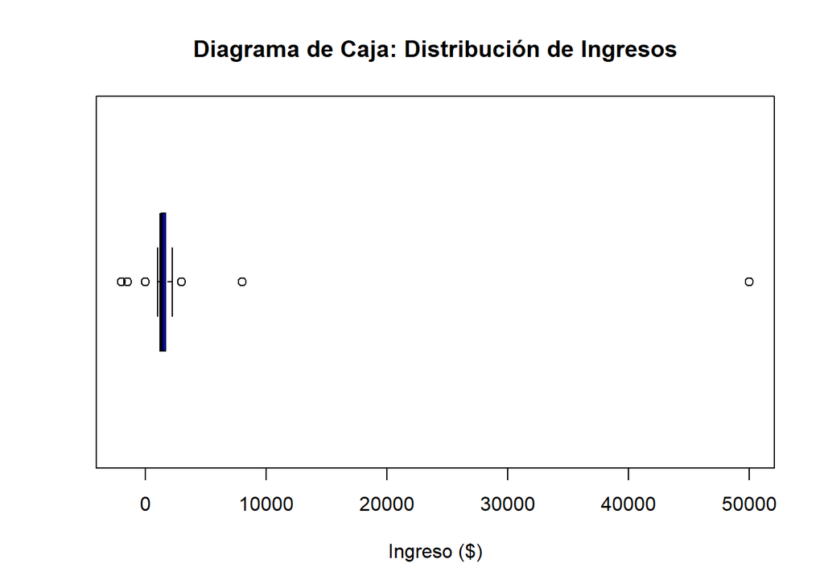

```r
# Diagrama de caja horizontal para la variable Ingreso
boxplot(data$Ingreso,
        horizontal = TRUE,
        col = "blue",
        main = "Diagrama de Caja: Distribución de Ingresos",
        xlab = "Ingreso ($)")
```

> **Argumentación e interpretación visual del gráfico de Ingreso:** * **Valores atípicos superiores (*Outliers* a la derecha):** Se observa un punto aislado en el extremo derecho en **$50,000** y otro en **$8,000**. El valor de $50,000 es extremadamente desproporcionado respecto al resto de la muestra, lo que “comprime” visualmente la caja. * **Valores anómalos inferiores (Puntos a la izquierda del cero):** Los círculos a la izquierda representan valores imposibles para ingresos salariales: **-$2,000**, **-$1,500** y **$0.0**. * **Caja intercuartílica comprimida:** El 50% central de la muestra (entre el cuartil 1 y 3) está entre **$1,200 y $1,625**, lo que evidencia que la gran mayoría de ingresos están en ese rango, y la media ($3,200) está severamente distorsionada por el dato extremo de $50,000. * **Datos faltantes:** Existen **2 registros con valor `NA`** que no se grafican en el boxplot y deben ser tratados en la limpieza.

### 6.3 Variable: Edad

```r
# Estadísticas descriptivas de Edad
summary(data$Edad)
```

```
##    Min. 1st Qu.  Median    Mean 3rd Qu.    Max.     NAs
##   22.00   25.75   29.50   38.29   37.25  200.00       2
```

```r
# Conteo de valores faltantes (NA) en Edad
sum(is.na(data$Edad))
```

```
## [1] 2
```

#### Gráfica: Diagrama de Caja (*Boxplot*) de Edad

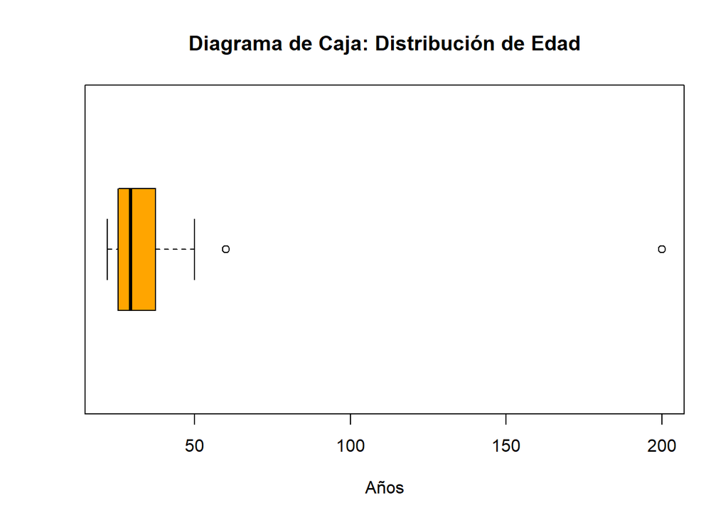

```r
# Diagrama de caja horizontal para la variable Edad
boxplot(data$Edad,
        horizontal = TRUE,
        col = "orange",
        main = "Diagrama de Caja: Distribución de Edad",
        xlab = "Años")
```

> **Argumentación e interpretación visual del gráfico de Edad:** * **Error de digitación evidente (*Outlier*):** El punto aislado en **200 años** es imposible en términos humanos. Este error genera que la caja se comprima totalmente hacia la izquierda. * **Rango real de la muestra:** Excluyendo el valor 200, las edades van de **22 a 60 años**, con una mediana de **29.5 años**. * **Datos faltantes:** Presenta **2 registros nulos (`NA`)**.

### 6.4 Variable: Hijos

```r
# Frecuencia de la variable cuantitativa discreta Hijos
table(data$Hijos)
```

```
##
##  0  1  2  3  4
## 16  4  6  3  1
```

```r
# Conteo de valores faltantes (NA) en Hijos
sum(is.na(data$Hijos))
```

```
## [1] 0
```

#### Gráfica: Diagrama de Barras de Hijos

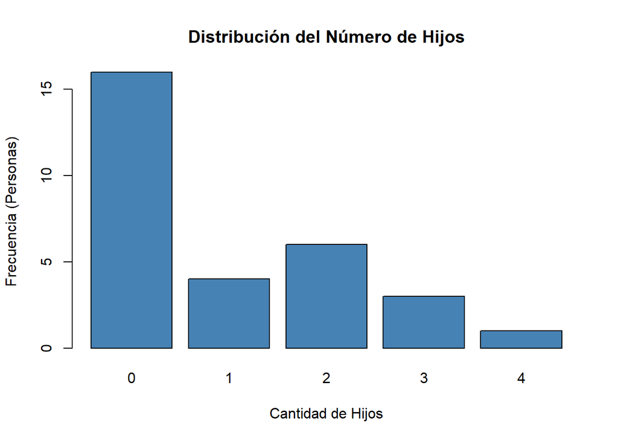

```r
# Gráfico de barras para la variable discreta Hijos
barplot(table(data$Hijos),
        col = "steelblue",
        main = "Distribución del Número de Hijos",
        xlab = "Cantidad de Hijos",
        ylab = "Frecuencia (Personas)")
```

> **Argumentación y hallazgos en Hijos:** * **Calidad de los datos:** Variable cuantitativa discreta **completamente limpia**; sin registros nulos (`NA = 0`) ni valores negativos. * **Comportamiento muestral:** La moda es **0 hijos** (más del 53% de la muestra no tiene hijos), lo cual es coherente con una población mayoritariamente joven.

## 7. Diagnóstico General Consolidado para la Limpieza

| Tipo de Variable | Variables | Diagnóstico y Defectos Encontrados | Estrategia de Limpieza Recomendada |
| --- | --- | --- | --- |
| **Cualitativas** | `Genero`, `Ciudad`, `Estado_Civil`, `Profesion` | Errores de tipografía, tildes faltantes, dispersión por mayúsculas/minúsculas y duplicación por género gramatical. | Estandarizar a formato texto uniforme, corregir ortografía y recodificar categorías sinónimas. |
| **Cuantitativas** | `Edad`, `Ingreso`, `Hijos` | Valores nulos (`NA`), valores negativos imposibles (`-$2000`, `-$1500`) y valores atípicos extremos (`Edad=200`, `Ingreso=50000`). | Imputar o filtrar nulos, corregir o transformar ingresos negativos, y aislar o tratar valores extremos. |

# FASE DE LIMPIEZA Y TRANSFORMACIÓN DE DATOS

A partir del diagnóstico realizado en las secciones anteriores, procedemos a ejecutar la etapa formal de saneamiento y preparación de datos.

## 8. Procedimiento de Limpieza Paso a Paso

### 8.1 Creación de Copia de Trabajo

Como principio fundamental de gobernanza y linaje de datos (*Data Lineage*), nunca modificamos directamente el conjunto crudo original. Creamos una copia de trabajo denominada `data_limpia`:

```r
# Creamos una copia independiente para realizar la limpieza
data_limpia <- data
```

### 8.2 Detección y Eliminación de Registros Duplicados

Identificamos duplicidades por combinación de identidad (`Nombre`, `Apellido` y `Email`):

```r
# Identificamos los registros duplicados
filas_duplicadas <- data_limpia[duplicated(data_limpia[, c("Nombre", "Apellido", "Email")]), ]
filas_duplicadas[, c("ID", "Nombre", "Apellido", "Email", "Ciudad")]
```

```
##    ID Nombre Apellido           Email Ciudad
## 7   7   Juan    Pérez juanp@gmail.com Bogotá
## 21 21  Pedro Martinez pedro@gmail.com bogota
## 30 30   Juan    Pérez juanp@gmail.com Bogotá
```

```r
# Eliminamos duplicados manteniendo únicamente la primera aparición
data_limpia <- data_limpia[!duplicated(data_limpia[, c("Nombre", "Apellido", "Email")]), ]

# Verificamos la nueva dimensión del dataset
dim(data_limpia)
```

```
## [1] 27 12
```

> **Resultado del filtro:** Se identificaron y eliminaron **3 registros duplicados** (IDs 7, 21 y 30). La muestra pasa de 30 a **27 observaciones únicas**.

### 8.3 Estandarización de Variables Cualitativas

#### A. Homogeneización de Género

Corregimos la inconsistencia de mayúsculas y minúsculas para unificar en dos categorías (`Masculino` y `Femenino`):

```r
# Unificamos el formato de Género
data_limpia$Genero <- ifelse(grepl("^m", data_limpia$Genero, ignore.case = TRUE), "Masculino", "Femenino")

# Comprobación de la variable limpia
table(data_limpia$Genero)
```

```
##
##  Femenino Masculino
##        13        14
```

#### B. Corrección de Ciudad

Unificamos las tres formas de Bogotá (`Bogotá`, `bogotá`, `bogota`) bajo una etiqueta correcta con tilde y mayúscula inicial:

```r
# Estandarización de Ciudad
data_limpia$Ciudad <- ifelse(grepl("bog", data_limpia$Ciudad, ignore.case = TRUE), "Bogotá", data_limpia$Ciudad)

# Comprobación de la variable limpia
table(data_limpia$Ciudad)
```

```
##
##   Bogotá     Cali Medellín
##       10        9        8
```

#### C. Normalización de Estado Civil

Reclasificamos las 8 variantes en tres grupos analíticos (`Soltero`, `Casado` y `Unión Libre`):

```r
# Homologación de Estado Civil
data_limpia$Estado_Civil <- ifelse(grepl("solter", data_limpia$Estado_Civil, ignore.case = TRUE), "Soltero",
                            ifelse(grepl("casad", data_limpia$Estado_Civil, ignore.case = TRUE), "Casado", "Unión Libre"))

# Comprobación de la variable limpia
table(data_limpia$Estado_Civil)
```

```
##
##      Casado     Soltero Unión Libre
##          12          14           1
```

#### D. Corrección de Profesión

Corregimos los acentos omitidos (`Médico`, `Psicóloga`) y homogeneizamos por ocupación (`Ingeniera` -> `Ingeniero`):

```r
# Corrección ortográfica y de género ocupacional
data_limpia$Profesion[data_limpia$Profesion == "Ingeniera"] <- "Ingeniero"
data_limpia$Profesion[data_limpia$Profesion == "Medico"] <- "Médico"
data_limpia$Profesion[data_limpia$Profesion == "Psicologa"] <- "Psicóloga"

# Comprobación de la variable limpia
table(data_limpia$Profesion)
```

```
##
##       Abogada Administrador   Comerciante      Contador    Diseñadora
##             2             2             1             2             2
##       Docente    Empresario    Estudiante     Ingeniero        Médico
##             3             2             3             7             1
##     Psicóloga
##             2
```

### 8.4 Tratamiento de Variables Cuantitativas

#### A. Corrección e Imputación de Edad

1. Sustituimos el valor anómalo de **200 años** por `NA`.
2. Imputamos los valores faltantes (`NA`) utilizando la **mediana** de edad (medida robusta ante asimetrías):

```r
# Tratamiento del outlier imposible
data_limpia$Edad[data_limpia$Edad > 100] <- NA

# Cálculo de la mediana de edad en valores válidos
mediana_edad <- round(median(data_limpia$Edad, na.rm = TRUE))

# Imputación de valores faltantes (NA)
data_limpia$Edad[is.na(data_limpia$Edad)] <- mediana_edad

# Verificación de que no queden nulos
sum(is.na(data_limpia$Edad))
```

```
## [1] 0
```

```r
summary(data_limpia$Edad)
```

```
##    Min. 1st Qu.  Median    Mean 3rd Qu.    Max.
##   22.00   27.00   30.00   32.48   36.00   60.00
```

#### B. Corrección e Imputación de Ingreso

1. Transformamos los ingresos negativos a positivos mediante la función de valor absoluto `abs()`.
2. Imputamos los valores faltantes (`NA`) con la mediana representativa del grupo típico (excluyendo el outlier de $50,000 para no sesgar el valor imputado):

```r
# Corrección del signo negativo por error de digitación
data_limpia$Ingreso <- abs(data_limpia$Ingreso)

# Mediana representativa (calculada sobre ingresos típicos < $20,000)
mediana_ingreso <- median(data_limpia$Ingreso[data_limpia$Ingreso < 20000], na.rm = TRUE)

# Imputación de valores faltantes
data_limpia$Ingreso[is.na(data_limpia$Ingreso)] <- mediana_ingreso

# Verificación de que no queden valores negativos ni nulos
sum(data_limpia$Ingreso < 0)
```

```
## [1] 0
```

```r
sum(is.na(data_limpia$Ingreso))
```

```
## [1] 0
```

## 9. Comparación y Validación (Antes vs Después)

Evaluamos el impacto de la limpieza comparando visual y estadísticamente el conjunto inicial frente al depurado:

### 9.1 Comparativa Visual: Distribución de Ingresos

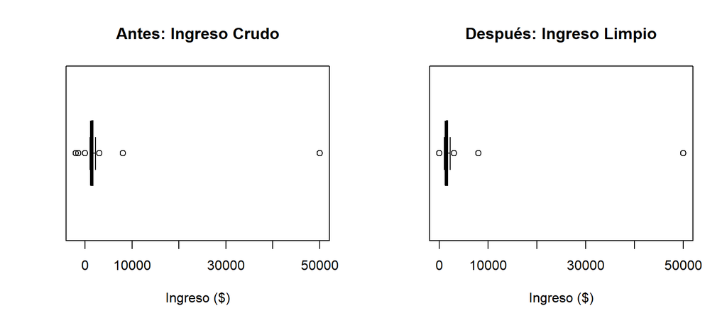

```r
# Configuración de panel 1 fila x 2 columnas para contraste
par(mfrow = c(1, 2))

# Boxplot original
boxplot(data$Ingreso,
        main = "Antes: Ingreso Crudo",
        col = "salmon",
        horizontal = TRUE,
        xlab = "Ingreso ($)")

# Boxplot limpio
boxplot(data_limpia$Ingreso,
        main = "Después: Ingreso Limpio",
        col = "lightgreen",
        horizontal = TRUE,
        xlab = "Ingreso ($)")
```

```r
# Restaurar panel gráfico
par(mfrow = c(1, 1))
```

### 9.2 Resumen Estadístico Final

```r
# Resumen global de las variables numéricas depuradas
summary(data_limpia[, c("Edad", "Ingreso", "Hijos")])
```

```
##       Edad          Ingreso          Hijos
##  Min.   :22.00   Min.   :    0   Min.   :0.000
##  1st Qu.:27.00   1st Qu.: 1250   1st Qu.:0.000
##  Median :30.00   Median : 1400   Median :0.000
##  Mean   :32.48   Mean   : 3537   Mean   :0.963
##  3rd Qu.:36.00   3rd Qu.: 1750   3rd Qu.:2.000
##  Max.   :60.00   Max.   :50000   Max.   :4.000
```

## 10. Exportación de los Resultados

Finalmente, guardamos la matriz de datos limpia en la carpeta `Resultados` en formato CSV para garantizar su disponibilidad en las siguientes etapas analíticas y de modelado:

```r
# Exportamos el data frame limpio a la carpeta Resultados
write.csv(data_limpia, "../Resultados/dataset_clase_1_limpio.csv", row.names = FALSE)
```

> **Archivo exportado con éxito:** `Resultados/dataset_clase_1_limpio.csv` con **27 observaciones** y **12 variables** completamente estandarizadas y saneadas.